# Fitting and Selecting ARIMA models

6 Apr 2023

## Box-Jenkins method

A. ARIMA(p,d,q) Model selection

1. Evaluate stationarity
2. Fix stationarity problems - Select the differencing level (d)
3. Selection of the AR level (p)
4. Selection of the MA level (q)

B. Parameter estimation

C. Model checking

1. Test model residuals for distribution assumptions (e.g. Normality)
2. Test model residuals for temporal correlation
- For ARIMA models, much of the Box-Jenkins method will be automated with the **forecast** package functions, which you will use in the lab.

## Stationarity

Stationarity means ‘not changing in time’ in the context of time-series models. Typically we test the trend and variance, however more generally all statistical properties of a time-series is time-constant if the time series is ‘stationary’.

## Example

Many ARMA models exhibit stationarity. White noise is one type: \[x_t = e_t, e_t \sim N(0,\sigma)\]

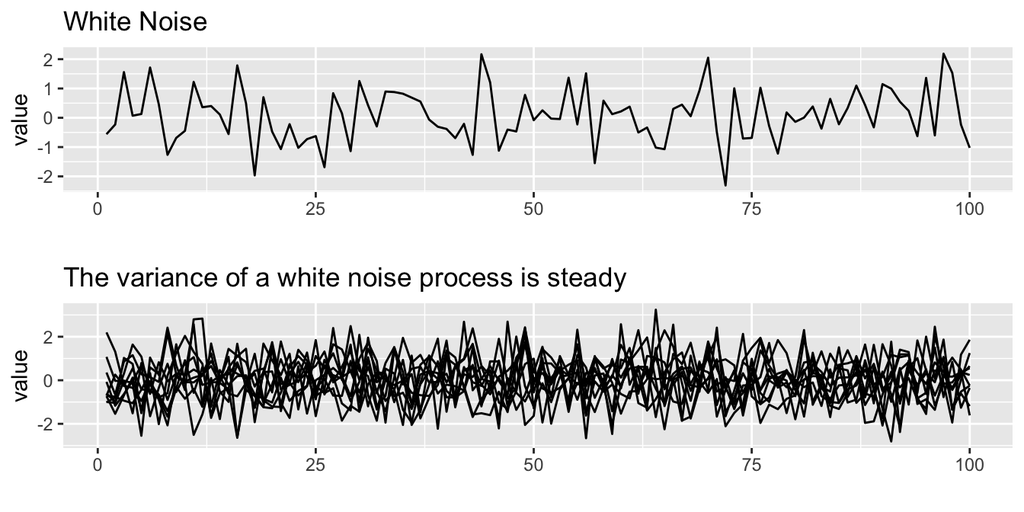

## Example

An AR-1 process with \(-1< \phi <1\) \[x_t = \phi x_{t-1} + e_t\] is also stationary.

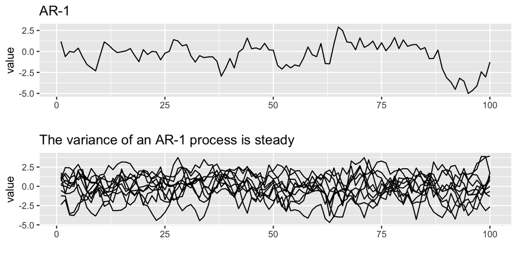

## Stationarity around non-zero mean

We can also have stationarity around a non-zero level or around a linear trend.

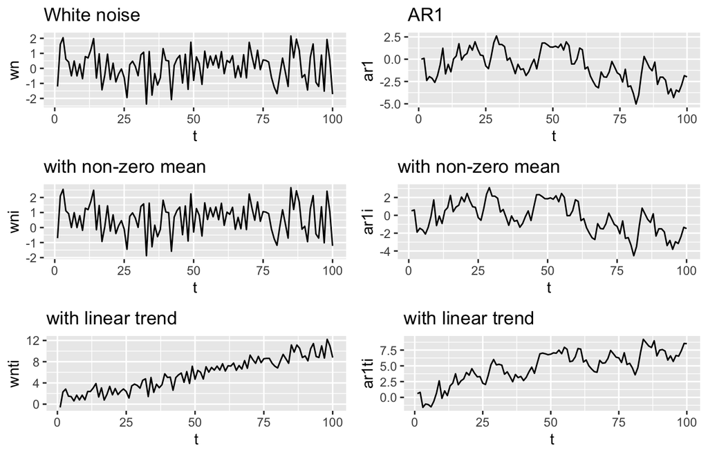

## Mathematically it looks like this

AR-1 (-1 < \(\phi\) < 1)

1. Non-zero mean adds \(\mu\): \(x_t = \mu + \phi x_{t-1} + e_t\)
2. Linear trend adds \(at\): \(x_t = \mu + at + \phi x_{t-1} + e_t\)

White noise (\(\phi=0\))

1. Non-zero mean: \(x_t = \mu + e_t\)
2. Linear trend: \(x_t = \mu + at + e_t\)

## Non-stationarity

One of the most common forms of non-stationarity that is tested for is that the process is a random walk \(x_t = x_{t-1} + e_t\). A random walk is called a ‘unit root’ process in the time series literature. A test for an underlying random walk is called a ‘unit root’ test.

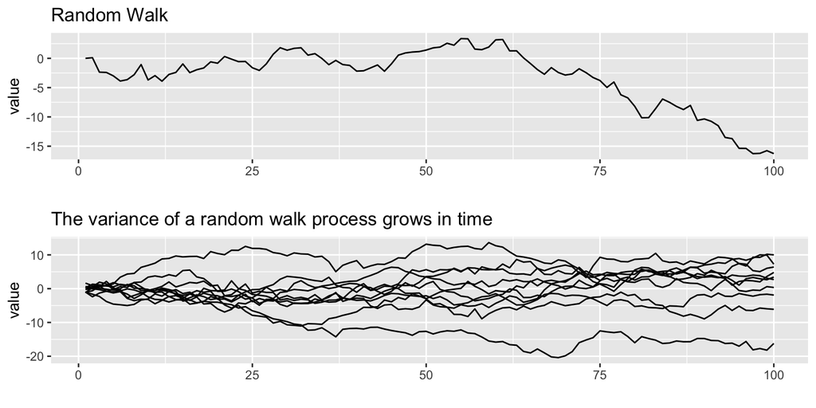

## Random walk with \(\mu\) and \(at\) added

Similar to the way we added an intercept and linear trend to stationary process equations, we can do the same to the random walk equation.

1. Non-zero mean or intercept: \(x_t = \mu + x_{t-1} + e_t\)
2. Linear trend: \(x_t = \mu + at + x_{t-1} + e_t\)

## Random walk with \(\mu\) and \(at\) added

The effects are fundamentally different however. The addition of \(\mu\) leads to a upward trend while the addition of \(at\) leads to exponential growth (or decline). All of these are “unit root” processes.

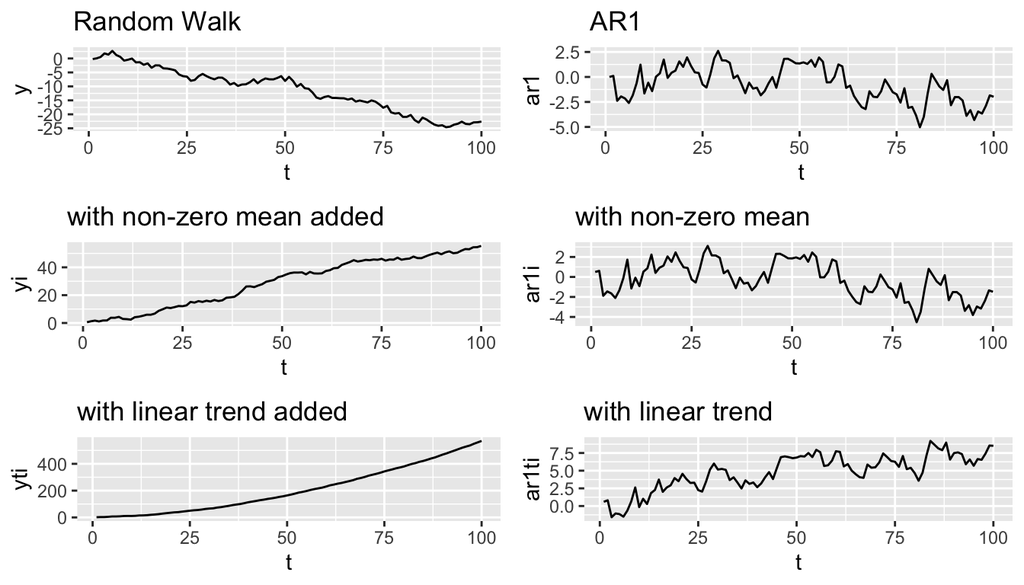

## Testing for stationarity

Why is evaluating stationarity important?

For this lecture, we are using the Box-Jenkins method for forecasting. Step 1 is to create a transformed stationary time series that we can fit an ARMA model to (Wold Decomposition).

In a real data analysis, there are other reasons:

- Many standard algorithms for fitting ARMA models assume stationarity.
- Many AR models are stationary. If your data are not, you are fitting a model that is fundamentally inconsistent with your data.
- Many processes in environmental science are fundamentally random walks, i.e. non-stationary, e.g. movement, population growth, genetic drift.

## Testing for stationarity

We will discuss three common approaches to evaluating stationarity:

- Visual test
- (Augmented) Dickey-Fuller test
- KPSS test

## Visual test

The visual test is simply looking at a plot of the data versus time. Look for

- Change in the level over time. Is the time series increasing or decreasing? Does it appear to cycle?
- Change in the variance over time. Do deviations away from the mean change over time, increase or decrease?

## Anchovy and sardine catch in Greek waters

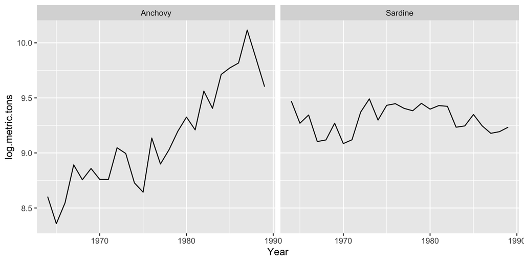

## Dickey-Fuller test

The Dickey=Fuller test (and Augmented Dickey-Fuller test) look for evidence that the time series has a unit root (a random walk process).

The **null hypothesis** is that the time series has a unit root, that is, it has a random walk component.

The **alternative hypothesis** is some variation of stationarity. The test has three main versions.

## Dickey-Fuller nulls and alternatives

It is hard to see but in the panels on the left, the variance around the trend is increasing and on the right, it is not.

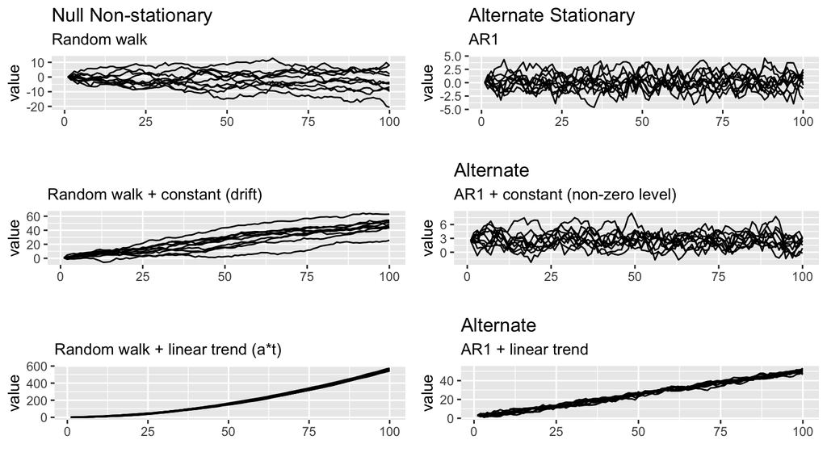

## Dickey-Fuller test using `tseries::adf.test()`

`adf.test()` in the tseries package will apply the Augmented Dickey-Fuller **with a constant and trend** and report the p-value. We want to reject the Dickey=Fuller null hypothesis of non-stationarity. We will set `k=0` to apply the Dickey-Fuller test which tests for AR(1) stationarity. The Augmented Dickey-Fuller tests for more general lag-p stationarity.

```
adf.test(x, alternative = c("stationary", "explosive"),
         k = trunc((length(x)-1)^(1/3)))
```

## Dickey-Fuller tests on the anchovy time series

Here is how to apply this test to the anchovy data. The null hypothesis is not rejected. That is not what we want.

```r
adf.test(anchovyts, k=0)
```

```
##
##  Augmented Dickey-Fuller Test
##
## data:  anchovyts
## Dickey-Fuller = -3.4558, Lag order = 0, p-value =
## 0.07003
## alternative hypothesis: stationary
```

## Dickey-Fuller test with `urca::ur.df`

The `urca` R package can also be used to apply the Dickey-Fuller tests. Use `lags=0` for Dickey-Fuller which tests for AR(1) stationarity. We will set `type="trend"` to deal with the trend seen in the anchovy data. Note, `adf.test()` uses this type by default.

```
ur.df(y, type = c("none", "drift", "trend"), lags = 0)
```

- none: \(x_t = \phi x_{t-1} + e_t\)
- drift: \(x_t = \phi x_{t-1} + \mu + e_t\)
- trend: \(x_t = \phi x_{t-1} + \mu + a t + e_t\)

## Dickey-Fuller test with ‘ur.df’

```r
test = urca::ur.df(anchovyts, type="trend", lags=0)
test
```

```
##
## ###############################################################
## # Augmented Dickey-Fuller Test Unit Root / Cointegration Test #
## ###############################################################
##
## The value of the test statistic is: -3.4558 4.3568 5.9805
```

## Dickey-Fuller test with ‘ur.df’

The test statistics and the critical values at \(\alpha = 0.05\) are

```r
attr(test, "teststat")
```

```
##                tau3     phi2     phi3
## statistic -3.455795 4.356764 5.980506
```

```r
attr(test,"cval")
```

```
##       1pct  5pct 10pct
## tau3 -4.15 -3.50 -3.18
## phi2  7.02  5.13  4.31
## phi3  9.31  6.73  5.61
```

\(x_t = \phi x_{t-1} + \mu + a t + e_t\)

\(x_t - x_{t-1} = \gamma x_{t-1} + \mu + a t + e_t\)

The hypotheses reported in the output are

- `tau` (or `tau2` or `tau3`): \(\gamma=0\)
- `phi` reported values: are for the tests that \(\gamma=0\) and/or the other parameters \(a\) and \(\mu\) are also 0.

Since we are focused on the random walk (non-stationary) test, we focus on the `tau` (or `tau2` or `tau3`) statistics and critical values

```r
attr(test, "teststat")
```

```
##                tau3     phi2     phi3
## statistic -3.455795 4.356764 5.980506
```

```r
attr(test,"cval")
```

```
##       1pct  5pct 10pct
## tau3 -4.15 -3.50 -3.18
## phi2  7.02  5.13  4.31
## phi3  9.31  6.73  5.61
```

The `tau3` statistic is larger than the critical value and thus the null hypothesis of non-stationarity is not rejected. That’s not what we want. Note, you can also get the test statistic and critical values at the bottom of the output from `urca::summary(test)`.

## KPSS test

The Kwiatkowski–Phillips–Schmidt–Shin (KPSS) test has as the null hypothesis that the time series is stationary around a level trend (or a linear trend). The alternative hypothesis for the KPSS test is a random walk.

```
tseries::kpss.test(x, null = c("Level", "Trend"))
```

The stationarity assumption is general; it does not assume a specific type of stationarity such as white noise.

If both KPSS and Dickey-Fuller tests support non-stationarity, then the stationarity assumption is not supported.

## KPSS test with the anchovy data

```r
tseries::kpss.test(anchovyts, null="Trend")
```

```
##
##  KPSS Test for Trend Stationarity
##
## data:  anchovyts
## KPSS Trend = 0.14779, Truncation lag parameter = 2,
## p-value = 0.04851
```

Here `null="Trend"` was included to account for the increasing trend in the data. The null hypothesis of stationarity is rejected. Thus both the KPSS and Dickey-Fuller tests support the hypothesis that the anchovy time series is non-stationary. That’s not what we want.

## Fix stationarity problems

In this lecture we will use differencing, the I in ARIMA model refers to differencing.

## Differencing the data to make the mean stationary

Differencing means to create a new time series \(z_t = x_t - x_{t-1}\). First order differencing means you do this once (so \(z_t\)) and second order differencing means you do this twice (so \(z_t - z_{t-1}\)).

The `diff()` function takes the first difference:

```r
x <- diff(c(1,2,4,7,11))
x
```

```
## [1] 1 2 3 4
```

The second difference is the first difference of the first difference.

```r
diff(x)
```

```
## [1] 1 1 1
```

## Anchovy catch first differenced

Here is a plot of the anchovy data and its first difference.

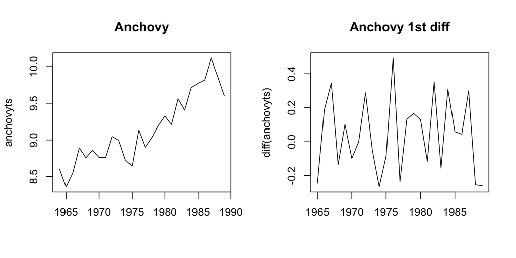

## Stationarity of the first differences

Let’s test the anchovy data with one difference using the KPSS test.

```r
diff.anchovy = diff(anchovyts)
kpss.test(diff.anchovy)
```

```
##
##  KPSS Test for Level Stationarity
##
## data:  diff.anchovy
## KPSS Level = 0.089671, Truncation lag parameter = 2,
## p-value = 0.1
```

The null hypothesis of stationairity is not rejected. That is good.

## Stationarity of the first differences

Let’s test the first difference of the anchovy data using the Augmented Dickey-Fuller test. We do the default test and allow it to chose the number of lags.

```r
adf.test(diff.anchovy)
```

```
##
##  Augmented Dickey-Fuller Test
##
## data:  diff.anchovy
## Dickey-Fuller = -3.2718, Lag order = 2, p-value =
## 0.09558
## alternative hypothesis: stationary
```

The null hypothesis of non-stationarity is not rejected. That is not what we want. However, we differenced which removed the trend thus we are testing against a more general model than we need. Let’s test with an alternative hypothesis that has a non-zero mean and no trend. We can do this with `ur.df()` and `type='drift'`.

```r
test <- ur.df(diff.anchovy, type="drift")
```

The test statistic and the critical values are

```r
attr(test, "teststat")
```

```
##                tau2     phi1
## statistic -5.108275 13.15327
```

```r
attr(test,"cval")
```

```
##       1pct  5pct 10pct
## tau2 -3.75 -3.00 -2.63
## phi1  7.88  5.18  4.12
```

The test statistic for \(\tau_2\) is less than the critical at \(\alpha\) equal 0.05. The null hypothesis of NON-stationairity IS rejected. That is good.

## `forecast::ndiffs()` function

As an alternative to trying many different differences, you can use the `ndiffs()` function in the forecast package. This automates finding the number of differences needed. `ndiff(x, test="adf")` also “knows” to use a different Augmented Dickey Fuller test after differencing.

```r
forecast::ndiffs(anchovyts, test="kpss")
```

```
## [1] 1
```

```r
forecast::ndiffs(anchovyts, test="adf")
```

```
## [1] 1
```

The test indicates that one difference (\(x_t - x_{t-1}\)) will lead to stationarity.

## Summary

Test stationarity before you fit a ARMA model.

**Visual test**: Do the data fluctuate around a level or do they have a trend or look like a random walk?

*Yes or maybe?* -> Apply a “unit root” test. ADF or KPSS

*No or fails the unit root test?* -> Apply differencing and re-test.

*Still not passing?* -> Try a second difference or you may need to transform the data (if say it has an exponential trend).

*Still not passing?* -> ARMA model might not be the best choice. Or you may need to use an adhoc detrend.

**These steps are automated by the forecast package**

## Box-Jenkins method

A. Model form selection

1. Evaluate stationarity
2. Selection of the differencing level (d) – to fix stationarity problems
3. **Selection of the AR level (p)**
4. **Selection of the MA level (q)**

**B. Parameter estimation**

C. Model checking

## ACF and PACF

On Tuesday, you learned how to use ACF and PACF to visually infer the AR and MA lags for a ARMA model. Here is the ACF and PACF of the differenced anchovy time series.

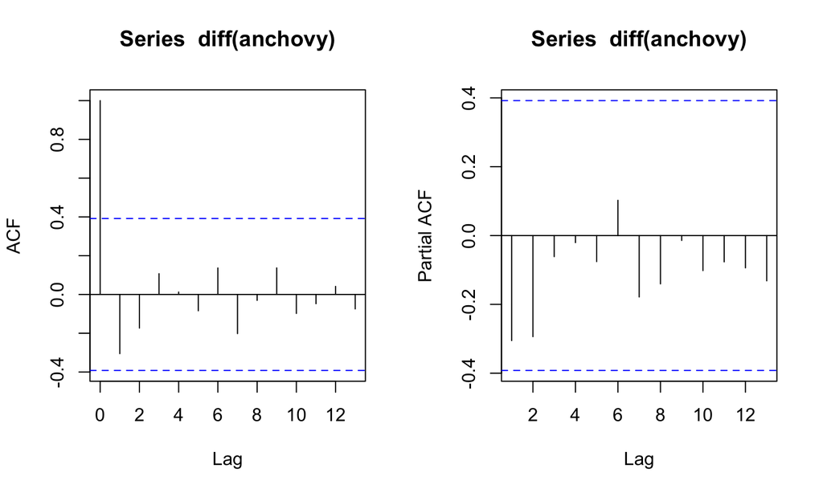

## Formal model selection

This weighs how well the model fits against how many parameters your model has. Basic idea is to fit (many) models and use AIC, AICc or BIC to select.

The `auto.arima()` function in the forecast package in R allows you to easily do this and will also select the level of differencing (via ADF or KPSS tests).

```r
forecast::auto.arima(anchovy)
```

Type `?forecast::auto.arima` to see a full description of the function.

## Model selection with `auto.arima()`

```r
forecast::auto.arima(anchovy)
```

```
## Series: anchovy
## ARIMA(0,1,1) with drift
##
## Coefficients:
##           ma1   drift
##       -0.6685  0.0542
## s.e.   0.1977  0.0142
##
## sigma^2 = 0.04037:  log likelihood = 5.39
## AIC=-4.79   AICc=-3.65   BIC=-1.13
```

The output indicates that the ‘best’ model is a MA(1) with first difference. “with drift” means that the mean of the anchovy first differences (the data for the model) is not zero.

## Trace = TRUE

By default, step-wise selection is used for the model search. You can see what models that `auto.arima()` tried using `trace=TRUE`. The models are selected on AICc by default.

```r
forecast::auto.arima(anchovy, trace=TRUE)
```

```
##
##  ARIMA(2,1,2) with drift         : 4.765453
##  ARIMA(0,1,0) with drift         : 0.01359746
##  ARIMA(1,1,0) with drift         : -0.1662165
##  ARIMA(0,1,1) with drift         : -3.647076
##  ARIMA(0,1,0)                    : -1.554413
##  ARIMA(1,1,1) with drift         : Inf
##  ARIMA(0,1,2) with drift         : Inf
##  ARIMA(1,1,2) with drift         : 1.653078
##  ARIMA(0,1,1)                    : -1.372929
##
##  Best model: ARIMA(0,1,1) with drift
```

```
## Series: anchovy
## ARIMA(0,1,1) with drift
##
## Coefficients:
##           ma1   drift
##       -0.6685  0.0542
## s.e.   0.1977  0.0142
##
## sigma^2 = 0.04037:  log likelihood = 5.39
## AIC=-4.79   AICc=-3.65   BIC=-1.13
```

## Selected model

First difference of the data is MA(1) with drift

\[x_t - x_{t-1} = \mu + w_t + \theta_1 w_{t-1}\]

where \(w_t\) is white noise.

## Fit to simulated AR(2) data

```r
set.seed(100)
a1 = arima.sim(n=100, model=list(ar=c(.8,.1)))
forecast::auto.arima(a1, seasonal=FALSE, max.d=0)
```

```
## Series: a1
## ARIMA(1,0,0) with non-zero mean
##
## Coefficients:
##          ar1     mean
##       0.6928  -0.5343
## s.e.  0.0732   0.2774
##
## sigma^2 = 0.7703:  log likelihood = -128.16
## AIC=262.33   AICc=262.58   BIC=270.14
```

The ‘best-fit’ model is AR(1) not AR(2).

## How often is the ‘true’ model is chosen

Let’s run 100 simulations of a AR(2) process and record the best fits.

```r
save.fits = rep(NA,100)
for(i in 1:100){
  a1 = arima.sim(n=100, model=list(ar=c(.8,.1)))
  fit = forecast::auto.arima(a1, seasonal=FALSE, max.d=0, max.q=0)
  save.fits[i] = paste0(fit$arma[1], "-", fit$arma[2])
}
```

Overwhelmingly the correct type of model (AR) is selected, but usually a simpler model of AR(1) is chosen over AR(2).

Table heading is AR order - MA order.

```r
table(save.fits)
```

```
## save.fits
## 1-0 2-0 3-0 4-0
##  74  20   5   1
```

## stepwise=FALSE

By default, step-wise selection is used and an approximation is used for the models tried in the model selection step. For a final model selection, you should turn these off to fit a large set of models.

```r
forecast::auto.arima(anchovy, stepwise=FALSE,
                     approximation=FALSE)
```

```
## Series: anchovy
## ARIMA(0,1,1) with drift
##
## Coefficients:
##           ma1   drift
##       -0.6685  0.0542
## s.e.   0.1977  0.0142
##
## sigma^2 = 0.04037:  log likelihood = 5.39
## AIC=-4.79   AICc=-3.65   BIC=-1.13
```

## Summary: model selection and fitting

- Once you have dealt with stationarity, you need to determine the order of the model: the AR part and the MA part.
- Although you could simply use `auto.arima()`, it is best to run `acf()` and `pacf()` on your data to understand it better. Definitely you want to plot your data and visually look for stationarity issues.
- Also evaluate if there are reasons to assume a particular structure.
  - Are you using an established model form, from say another paper?
  - Are you fitting to a process that is fundamentally AR only or AR + MA?

## Box-Jenkins method

A. Model form selection

1. Evaluate stationarity
2. Selection of the differencing level (d) – to fix stationarity problems
3. Selection of the AR level (p)
4. Selection of the MA level (q)

B. Parameter estimation

**C. Model checking**

## Check the residuals

Residuals = difference between the expected (fitted) value of \(x_t\) and the data

There is no observation error in an ARMA model. The expected value is the \(x_t\) expected from data up to \(t-1\).

For example, the residual for an AR(2) model is \(y_t - \hat{x}_t\).

\(x_t = \phi_1 x_{t-1} + \phi_2 x_{t-2} + w_t\)

\(\hat{x}_t = \phi_1 x_{t-1} + \phi_2 x_{t-2}\)

## `residuals()` function in R

The `residuals()` function will return the residuals for fitted models.

```r
fit <- forecast::auto.arima(anchovy)
residuals(fit)
```

```
## Time Series:
## Start = 1
## End = 26
## Frequency = 1
##  [1]  0.008549039 -0.249032308 -0.004098059  0.281393071
##  [5] -0.006015194  0.043859685 -0.123711732 -0.137125900
##  [9]  0.142098844 -0.011246624 -0.328608840 -0.358310373
## [13]  0.198311913 -0.157824727 -0.028321380  0.092732171
## [17]  0.136826748 -0.078995675  0.245238274 -0.046755189
## [21]  0.222279848  0.153983301  0.093036353  0.307250228
## [25] -0.103051063 -0.383026466
```

## `fitted()` function in R

The `fitted()` function will return the expected values. Remember that for a ARMA model, these are the expected values conditioned on the data up to time \(t-1\).

```r
fitted(fit)
```

```
## Time Series:
## Start = 1
## End = 26
## Frequency = 1
##  [1] 8.594675 8.606878 8.550151 8.610325 8.762619 8.814978
##  [7] 8.883569 8.896418 8.905111 9.006436 9.056857 9.002066
## [13] 8.937456 9.057378 9.059236 9.104026 9.188947 9.288486
## [19] 9.316477 9.451955 9.490634 9.618501 9.723727 9.808749
## [25] 9.964784 9.984801
```

The residuals are `data` minus `fitted`.

## Standard residuals tests

- Plot the residuals. They should look roughly like white noise.
- Look at the ACF of the residuals. They should be uncorrelated.
- Look at the histogram. They should be normally distributed (if that is your error assumption).

## Residuals check with forecast package

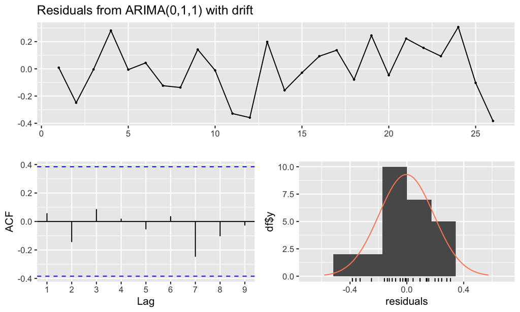

```r
forecast::checkresiduals(fit)
```

## Test for autocorrelation

The standard test for autocorrelated time-series residuals is the Ljung-Box test. The null hypothesis for this test is **no autocorrelation**. We do not want to reject the null.

```r
forecast::checkresiduals(fit, plot=FALSE)
```

```
##
##  Ljung-Box test
##
## data:  Residuals from ARIMA(0,1,1) with drift
## Q* = 1.0902, df = 4, p-value = 0.8958
##
## Model df: 1.   Total lags used: 5
```

\(p>0.05\) would be interpreted as not enough statistical evidence to reject the null hypothesis.